# Spatial Autocorrelation

Mariam Walaa

```r
library(rgdal)
library(pgirmess)
library(spdep)
library(classInt)
library(RColorBrewer)
```

This part will use the U.S. Census 2010 data on the Hispanic population in Salt Lake County, estimated at the census tract level of aggregation. The shape file is projected into U.T.M. Zone 12 coordinates (i.e. coordinates measured in meters). The shape file of census tracts will be loaded into a spatial object below.

### Loading and Plotting

The shape file of census tracts in Salt Lake Country has 32 fields and 211 features. A choropleth map of the HIS_PCT variable is created below using the quantile classification method, a sequential color scheme, and 5 classes. The HIS_PCT variable is the proportion of Hispanic people in each census tract. The quantile classification method bins the variable of interest into groups of equal size and is chosen for this map as it seems to visually display more variation than Jenks natural breaks or standard deviation. The sequential color scheme is chosen since it makes sense to use a lighter value to represent lower proportions of Hispanic people within a census tract and a higher value to represent higher proportions of Hispanic people within a census tract. The number of classes chosen is 5.

```r
SLCCT <- readOGR(dsn = "../data/tutorial_saltlake", layer = "SLC_CT2010")
```

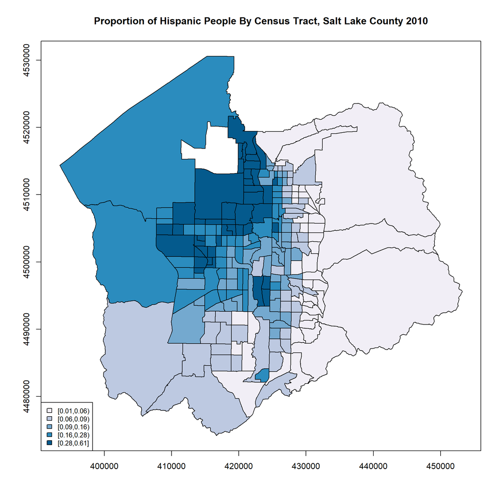

```r
# Define the number of classes.
nclasses <- 5

# Define the classification method. Available methods include: "equal", "sd", "quantile", "kmeans", "jenks"
class <- classIntervals(var = SLCCT$HIS_PCT, n = nclasses, style = "quantile", dataPrecision = 2)

# Set color palette.
colcode <- findColours(clI = class, pal = brewer.pal(nclasses, "PuBu"), digits = 3)

# Plot the map.
plot(SLCCT, col = colcode, border = "black", axes = T)

# Add a title.
title(main = "Proportion of Hispanic People By Census Tract, Salt Lake County 2010")

# Add a legend.
legend("bottomleft", legend = names(attr(colcode, "table")), fill = attr(colcode, "palette"), cex = 0.8)
```

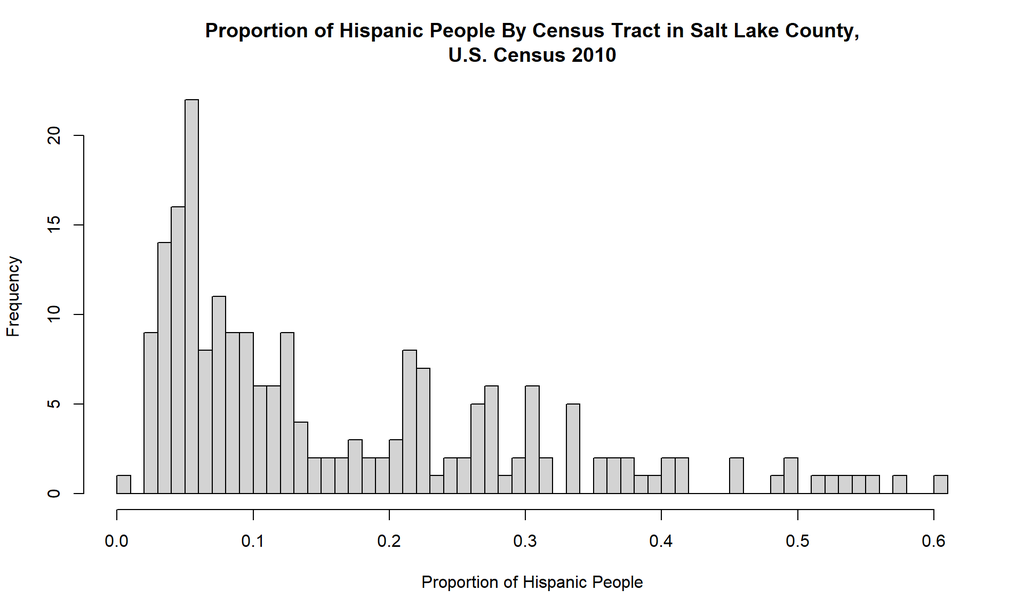

```r
hist(x = SLCCT$HIS_PCT, breaks = 60, xlab = "Proportion of Hispanic People",
     main = paste("Proportion of Hispanic People By Census Tract in Salt Lake County,",
                "U.S. Census 2010", sep = "\n"))
```

```r
summary(SLCCT$HIS_PCT)
```

```
##     Min.  1st Qu.   Median     Mean  3rd Qu.     Max.
## 0.007463 0.055368 0.110574 0.165272 0.249988 0.604172
```

### Working with Neighbor Lists

The relationships between the census tracts can be explored in order to measure spatial autocorrelation using neighbor graphs and weights. This is a two-step process that consists of first choosing the neighbor criterion that needs to be satisfied and then choosing the method to assign weights to the identified neighbor links. For the first step, the spatial object storing the census tract geographic data has been used in the process of creating graphs of two different neighbor criterion types (Rook and Queen).The Queen neighbors list is expected to contain more links since the queen condition can be met by a single shared boundary point, while the rook condition can only be met by more than one shared point.

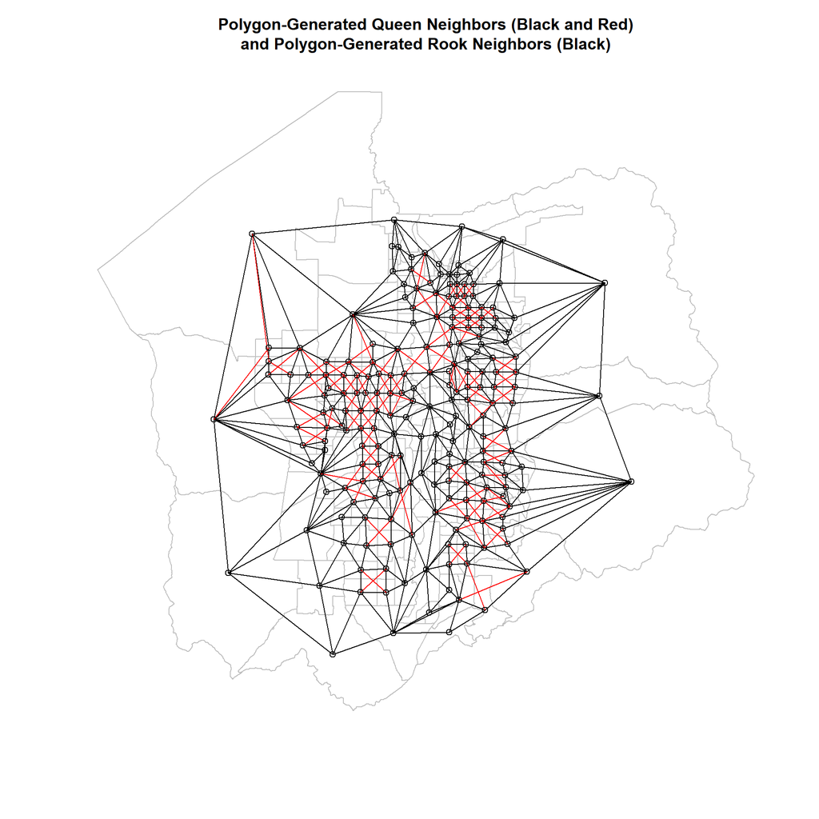

```r
# Retrieve coordinates from spatial object.
coords <- coordinates(SLCCT)

# Create a rook contiguity neighbor list.
SLCnb_rook <- poly2nb(pl = SLCCT, queen = FALSE)

# Create a queen contiguity neighbor list.
SLCnb_queen <- poly2nb(pl = SLCCT)

# Find differences between the two contiguity neighbor lists.
diff_nb <- diffnb(x = SLCnb_queen, y = SLCnb_rook)

# Plot the census tract boundaries.
plot(x = SLCCT, border = "grey")

# Plot the queen neighbors.
plot(x = SLCnb_queen, coords, add = TRUE, col = "black")

# Plot the differences between the rook and queens neighbor lists.
plot(x = diff_nb, coords, add = TRUE, col = "red")

# Add a title.
title(main = paste("Polygon-Generated Queen Neighbors (Black and Red)",
                 "and Polygon-Generated Rook Neighbors (Black)", sep = "\n"))
```

```r
summary(card(SLCnb_rook))
```

```
##    Min. 1st Qu.  Median    Mean 3rd Qu.    Max.
##   3.000   4.000   5.000   5.185   6.000  13.000
```

```r
summary(card(SLCnb_queen))
```

```
##    Min. 1st Qu.  Median    Mean 3rd Qu.    Max.
##   3.000   5.000   6.000   6.474   7.000  14.000
```

The summary statistics of the Rook and Queen neighbors shows that none of the methods have a normal distribution, and the Queen neighbor list contains more links as expected. This has been achieved using the helper function card which provides the cardinality of the neighbor set. The neighbor map shows that there are many more neighbor links through the queen condition than the rook condition. This is especially the case in areas where there are smaller census tracts (north east and north west of the center of the map). This can be confirmed by the number of nonzero links given by summary(SLCnb_queen), which show there are about 300 more links using the queen condition.

### Creating Weight Matrices from Neighbor Lists

For the second step, matrices of weights have been created for the neighbor lists. These weight matrices are contained in a listw object which is made up of the following three attributes:

- The style of the weight matrix, which can be ‘B’ (binary), ‘W’ (row-normalized), etc.
- The input neighbors list, which is a list of values representing the number of neighbors for each region
- The weights for each neighbor link based on the chosen style, which is a list of lists where each sublist contains weights for that region (if using ‘W’ style, each region will have different weights based on the number of neighbors the region has)

```r
# Create binary weight matrices
SLCnb_rook_B <- nb2listw(SLCnb_rook, style = "B")
SLCnb_queen_B <- nb2listw(SLCnb_queen, style = "B")

# Create normalized weight matrices
SLCnb_rook_W <- nb2listw(SLCnb_rook, style = "W")
SLCnb_queen_W <- nb2listw(SLCnb_queen, style = "W")

SLCnb_queen_B$weights[1]
```

```
## [[1]]
## [1] 1 1 1 1 1 1 1 1 1
```

```r
SLCnb_queen_W$weights[1]
```

```
## [[1]]
## [1] 0.1111111 0.1111111 0.1111111 0.1111111 0.1111111 0.1111111 0.1111111
## [8] 0.1111111 0.1111111
```

```r
SLCnb_rook_B$weights[1]
```

```
## [[1]]
## [1] 1 1 1 1 1 1
```

```r
SLCnb_rook_W$weights[1]
```

```
## [[1]]
## [1] 0.1666667 0.1666667 0.1666667 0.1666667 0.1666667 0.1666667
```

The weights object is a list of lists where each sub-list contains all the weights for a census tract. For example, the first observation has 9 neighbor weights using the queen condition and 6 neighbor weights using the rook condition. The weights for each neighbor of a single observation or census tract are represented as 1s using the binary weighting scheme and as decimals using the row-normalized weighting scheme. The values in the row-normalized matrix are based on the number of neighbors for that observation.

### Global Moran’s I

```r
# Compute Global Moran's I for each weight matrix
print(moran.test(SLCCT$HIS_PCT, listw = SLCnb_rook_B))
```

```
##
##  Moran I test under randomisation
##
## data:  SLCCT$HIS_PCT
## weights: SLCnb_rook_B
##
## Moran I statistic standard deviate = 18.791, p-value < 2.2e-16
## alternative hypothesis: greater
## sample estimates:
## Moran I statistic       Expectation          Variance
##       0.785957000      -0.004761905       0.001770772
```

```r
print(moran.test(SLCCT$HIS_PCT, listw = SLCnb_rook_W))
```

```
##
##  Moran I test under randomisation
##
## data:  SLCCT$HIS_PCT
## weights: SLCnb_rook_W
##
## Moran I statistic standard deviate = 18.812, p-value < 2.2e-16
## alternative hypothesis: greater
## sample estimates:
## Moran I statistic       Expectation          Variance
##       0.800642013      -0.004761905       0.001833075
```

```r
print(moran.test(SLCCT$HIS_PCT, listw = SLCnb_queen_B))
```

```
##
##  Moran I test under randomisation
##
## data:  SLCCT$HIS_PCT
## weights: SLCnb_queen_B
##
## Moran I statistic standard deviate = 19.76, p-value < 2.2e-16
## alternative hypothesis: greater
## sample estimates:
## Moran I statistic       Expectation          Variance
##       0.736971498      -0.004761905       0.001409101
```

```r
print(moran.test(SLCCT$HIS_PCT, listw = SLCnb_queen_W))
```

```
##
##  Moran I test under randomisation
##
## data:  SLCCT$HIS_PCT
## weights: SLCnb_queen_W
##
## Moran I statistic standard deviate = 20.502, p-value < 2.2e-16
## alternative hypothesis: greater
## sample estimates:
## Moran I statistic       Expectation          Variance
##       0.778577913      -0.004761905       0.001459817
```

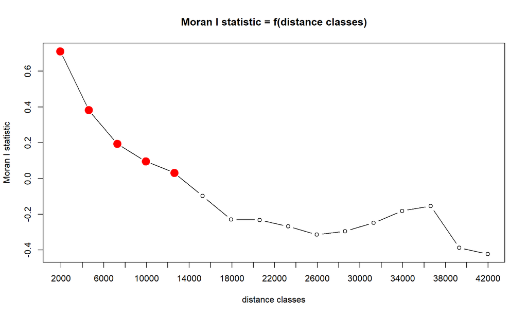

```r
# Compute and plot Moran's I for different distances
plot(correlog(coords, SLCCT$HIS_PCT, method = "Moran"))
```

This is a plot of global Moran’s I values for the percentage of Hispanic people in each census tract using different distances. The plot highlights the distances for which the Moran’s I statistic is statistically significant. The plot shows that a distance class around 2000 provides the largest Moran’s I statistic of above 0.6, while larger distance classes result in less autocorrelation.